# Enron Email Analysis

Phuc Nguyen PHAM

2024-11-24

## 1. Introduction

The Enron scandal, one of the largest corporate frauds in history, provides an important case study for data analysis. This project aims to analyze the Enron email data to uncover patterns, identify key contributors, and provide insights into communication dynamics within the company.

## 2. Objectives of the Project

The goal of the project is to explore and analyze various aspects of the email dataset from the conversations of Enron employees during the period before and during the company’s bankruptcy. The main analyses will include:

- Identifying the most active employees in the Enron email database.
- Analyzing user roles and their influence on communication.
- Exploring the temporal dynamics of emails, including correlations with significant public events.
- Performing a basic content analysis of email subjects to extract common themes.

## 3. Data Preparation and Cleaning

### 3.1 Loading and Inspecting Data

```r
# Load data
load(file = "Enron.Rdata")
```

In the Environment section, we notice that there are a total of 4 tables, of which 3 main tables according to the assignment are “employeelist”, “message”, and “recipientinfo”.

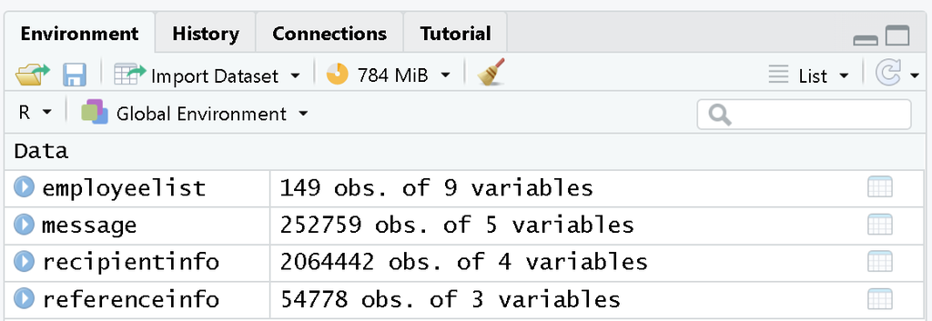

### 3.2 Data cleaning and ETL process

The purpose of the process is to clean the data, transform the tables, connect the tables into a star model, and denormalize the data to make it suitable for retrieval and analysis.

We will have a first look at each table

```r
head(employeelist)
```

```
##   eid firstName lastName                Email_id                     Email2
## 1  13     Marie    Heard   marie.heard@enron.com
## 2   6      Mark   Taylor mark.e.taylor@enron.com      mark.taylor@enron.com
## 3  19     Lindy   Donoho  lindy.donoho@enron.com          ldonoho@enron.com
## 4 115      Lisa     Gang     lisa.gang@enron.com
## 5 129   Jeffrey Skilling jeff.skilling@enron.com jeffrey.skilling@enron.com
## 6  18      Lynn    Blair    lynn.blair@enron.com        lynnblair@enron.com
##               Email3 EMail4     folder   status
## 1                              heard-m     <NA>
## 2 e.taylor@enron.com          taylor-m Employee
## 3                             donoho-l Employee
## 4                               gang-l      N/A
## 5                           skilling-j      CEO
## 6                              blair-l Director
```

```r
head(message)
```

```
##   mid                    sender       date
## 1  52   press.release@enron.com 2000-01-21
## 2  53 office.chairman@enron.com 2000-01-24
## 3  54 office.chairman@enron.com 2000-01-24
## 4  55   press.release@enron.com 2000-02-02
## 5  56 office.chairman@enron.com 2000-02-07
## 6  57          foothi19@idt.net 2000-08-25
##                                      message_id
## 1 <12435833.1075863606729.JavaMail.evans@thyme>
## 2 <29664079.1075863606676.JavaMail.evans@thyme>
## 3 <15300605.1075863606629.JavaMail.evans@thyme>
## 4 <10522232.1075863606538.JavaMail.evans@thyme>
## 5 <16056123.1075863606515.JavaMail.evans@thyme>
## 6 <31680362.1075863730221.JavaMail.evans@thyme>
##                                                                               subject
## 1 ENRON HOSTS ANNUAL ANALYST CONFERENCE PROVIDES BUSINESS OVERVIEW AND GOALS FOR 2000
## 2                                                     Over $50 -- You made it happen!
## 3                                                     Over $50 -- You made it happen!
## 4                 ROAD-SHOW.COM Q4i.COM CHOOSE ENRON TO DELIVER FINANCIAL WEB CONTENT
## 5                                                        Fortune Most Admired Ranking
## 6                                                   WPTF Friday Credo Veritas Burrito
```

```r
head(recipientinfo)
```

```
##   rid mid rtype                            rvalue
## 1  67  52    TO           all.worldwide@enron.com
## 2  68  53    TO            all.downtown@enron.com
## 3  69  54    TO     all.enron-worldwide@enron.com
## 4  70  55    TO           all.worldwide@enron.com
## 5  71  56    TO all_enron_north.america@enron.com
## 6  72  56    TO       ec.communications@enron.com
```

```r
str(referenceinfo)
```

```
## 'data.frame':    54778 obs. of  3 variables:
##  $ rfid     : int  2 3 8 13 14 15 16 17 18 19 ...
##  $ mid      : int  79 99 533 842 845 846 847 848 849 851 ...
##  $ reference: chr  "> From: Le Vine, Debi> Sent: Thursday, August 17, 2000 6:29 PM> To: ISO Market Participants> Subject: Request f"| __truncated__ "> From: Golden, Mark> Sent: Thursday, August 24, 2000 4:02 PM> To: Pergher, Gunther> Subject: Calif Gov Hopes T"| __truncated__ "From: Sole, JeanneS…
```

#### 3.2.1 Converting the Employeelist Table to the Emails Table

First, when we look at the “employeelist” table, we notice that this table contains 4 columns just to describe the employee’s emails.

Therefore, we will unpivot them to transform into a single email column. However, this will cause the employee ID primary key (eid) to appear multiple times and no longer be unique. Additionally, each employee can have multiple emails, but each email can only be owned by one employee, so we can still fully retrieve the employee once we know their email.

Thus, the proposed solution is to create a new table named “Emails”, with the primary key being the employee’s email.

```r
#install the package
library(dplyr)
library(tidyr)
library(lubridate)
#Create Emails Table

#First of all, we will do the data transformation for the "employeelist" table.

#We change the type of the “status” column to character instead of factor.
employeelist$status = as.character(employeelist$status)

#We also change the “eid” column from "num" to "int" because IDs are whole numbers and do not have decimal numbers.
employeelist$eid = as.integer(employeelist$eid)

#We will create a new table, namely "Emails":
emails = employeelist %>% pivot_longer( #Unpivot all the emails columns
  cols = c(Email_id, Email2, Email3, EMail4),
         names_to = "email",
         values_to = "email_id") %>% #We rename the new column to "email_id"

  #We don't select the "folder" column as it is useless
  select(email_id, eid, firstName, lastName, status) %>%

  #Remove rows with empty emails, because there are some cases where some people only have one email, so the Email2, Email3, Email4 columns will be empty.
  filter(email_id != "") %>%

  #We rename the "eid" column to "employee_id" so it will be easier to read
  rename(employee_id = eid) %>%

  #For the "status" column, we will re-label it, if the employees don't have the title (status is NA or empty), they will be labeled as "Unknown", if they have it, we will keep the status's value.
  mutate(status = trimws(status)) %>%
  mutate(status = ifelse(
    is.na(status) |
    toupper(status) == "N/A" |
    toupper(status) == "NA" |
    status == "" |
    is.null(status), "Unknown", status ))

#We will remove the "employeelist" to save the stockage
rm(employeelist)

print(emails)
```

```
## # A tibble: 297 × 5
##    email_id                   employee_id firstName lastName status
##    <chr>                            <int> <chr>     <chr>    <chr>
##  1 marie.heard@enron.com               13 Marie     Heard    Unknown
##  2 mark.e.taylor@enron.com              6 Mark      Taylor   Employee
##  3 mark.taylor@enron.com                6 Mark      Taylor   Employee
##  4 e.taylor@enron.com                   6 Mark      Taylor   Employee
##  5 lindy.donoho@enron.com              19 Lindy     Donoho   Employee
##  6 ldonoho@enron.com                   19 Lindy     Donoho   Employee
##  7 lisa.gang@enron.com                115 Lisa      Gang     Unknown
##  8 jeff.skilling@enron.com            129 Jeffrey   Skilling CEO
##  9 jeffrey.skilling@enron.com         129 Jeffrey   Skilling CEO
## 10 lynn.blair@enron.com                18 Lynn      Blair    Director
## # ℹ 287 more rows
```

Some data transforming processes have been executed, such as changing the label of the “status” column and removing the “folder” column because it is not useful and does not provide any information.

We will check whether these emails are unique and if there are cases where one email is used by two employees.

```r
#Check if there are any duplication for the "email_id" column
any(duplicated(emails$email_id))
```

```
## [1] FALSE
```

```r
# We create a query to make a list of emails that are possessed by more than one employee.
duplicated_emails = emails %>%
  group_by(email_id) %>%
  filter(n_distinct(employee_id) > 1)

# Check whether the emails are used exclusively by one employee
nrow(duplicated_emails) ==0
```

```
## [1] TRUE
```

```r
#Remove the table that we have created from the environment to save space
rm(duplicated_emails)
```

From the results, we can see that this new “emails” table can be used as the primary key “email_id” is unique , and there are no cases where multiple employees use the same email. This can help us retrieve employee information from the emails they use.

#### 3.2.2 Transforming the remaining 3 tables into one table named “Activities”

We can denormalize the 3 tables “message”, “recipientinfo”, and “referenceinfo” into a new table to serve the analysis step as it will improve the read performance of the database.

First, we will check if the “mid” column in the “referenceinfo” table is duplicated, as typically an email represents a single unique content, so there cannot be two contents in one email.

Then, the “mid” column in the “referenceinfo” table will be used as the primary key to merge with the “message” table.

After that, in the “message” table, “mid” is also the primary key, so it can be used to merge with the “recipientinfo” table. We will also remove the “message_id” column in the “message” table because it does not provide any useful information.

```r
#Create the "activities" table

#Check if there is any duplication for the "mid" column in the reference table
any(duplicated(referenceinfo$mid))
```

```
## [1] FALSE
```

```r
#Now we will join the tables

#We use the left join function to
merged_message = left_join(message, referenceinfo, by = "mid")

merged_recipient = left_join(recipientinfo, merged_message, by = "mid")

activities = merged_recipient %>%
  mutate(activity_id = row_number())

#We wil create the activities table
activities = activities %>%

  #First of all, we change the types and names of the columns (email of recipient, email of sender ans id of message, type of recipient) so we can read easily
  mutate(rvalue = as.character(rvalue)) %>%
  rename(email_recipient = rvalue) %>%
  mutate(sender = as.character(sender)) %>%
  rename(email_sender = sender) %>%
  mutate(rtype = as.character(rtype)) %>%
  rename(recipient_type = rtype) %>%
  mutate(mid = as.integer(mid)) %>%
  rename(mes_id = mid) %>%

  #Then, we remove some columns that are unnecessary.
  select(-rfid) %>%
  select(-rid) %>%
  select(-message_id) %>%

  #We also transform the date type date, and create 3 columns to express the year, month and day of the message
  mutate(date = as.Date(date, format = "%Y-%m-%d")) %>%
  mutate(year = year(date),month = month(date),day = day(date)) %>%
  mutate(year = as.integer(year), month = as.integer(month), day = as.integer(day)) %>%

  #For the "subject" column, we know that we can send, respond, or forward a message, so we will create 2 columns :

  #A subject type column which helps to categorizes the subject, if it begins with "RE:", so it means people responded an email, if it begins with "FW:", it means people forwarded an email, if not, it means people sent an email. We also use "grepl" for matching and replacement, and ignore.case to ignore lower case and upper case differences.
  mutate(subject_type = ifelse(grepl("^RE:", subject,ignore.case = TRUE), "RE",
                        ifelse(grepl("^FW:", subject, ignore.case = TRUE), "FW","Send"))) %>%

  #We create the subject content column in order to show only the content of the subject, regardless it is a normal, responded or forwarded email, and we will trim and make it to be a lowercase.
  mutate(subject_content = ifelse(subject_type == "RE", sub("^RE:", "", subject, ignore.case = TRUE),
                           ifelse(subject_type == "FW", sub("^FW:", "", subject, ignore.case = TRUE), subject))
  ) %>%
  mutate(subject_content = trimws(subject_content)) %>%
  mutate(subject_content = tolower(subject_content)) %>%
  select(activity_id, everything())

#Remove the table to save space
rm(message, merged_message,recipientinfo,merged_recipient, referenceinfo)

#Show the result
head(activities)
```

```
##   activity_id mes_id recipient_type                   email_recipient
## 1           1     52             TO           all.worldwide@enron.com
## 2           2     53             TO            all.downtown@enron.com
## 3           3     54             TO     all.enron-worldwide@enron.com
## 4           4     55             TO           all.worldwide@enron.com
## 5           5     56             TO all_enron_north.america@enron.com
## 6           6     56             TO       ec.communications@enron.com
##                email_sender       date
## 1   press.release@enron.com 2000-01-21
## 2 office.chairman@enron.com 2000-01-24
## 3 office.chairman@enron.com 2000-01-24
## 4   press.release@enron.com 2000-02-02
## 5 office.chairman@enron.com 2000-02-07
## 6 office.chairman@enron.com 2000-02-07
##                                                                               subject
```

[output cut: 20 more lines]

Then, we will create our own function to check if the data is cleaned or not. It will be useful because we can check if there is any data having the value of NA, NULL or the empty value.

```r
is_cleaned = function(x) { !(
  anyNA(x) |
  any(toupper(x) == "N/A") |
  any(toupper(x) == "NA") |
  any(x == "") |
  any(is.null(x))
)}
```

We changed the name of the “mesid” column, it will be “mes_id”. We check if the data are well cleaned:

```r
is_cleaned(activities$mes_id)
```

```
## [1] TRUE
```

```r
is_cleaned(emails$email_id)
```

```
## [1] TRUE
```

```r
is_cleaned(emails$employee_id)
```

```
## [1] TRUE
```

```r
is_cleaned(activities$email_sender)
```

```
## [1] TRUE
```

After completing the cleaning and ETL process, the data is now well-structured with appropriately typed columns. We will proceed to the data exploration phase to examine some statistics and further refine the data if necessary.

## 4. Data exploration and statistics

First of all, we need to see the summary of each table created:

```r
summary(activities)
```

```
##   activity_id          mes_id       recipient_type     email_recipient
##  Min.   :      1   Min.   :    52   Length:2064442     Length:2064442
##  1st Qu.: 516111   1st Qu.:105438   Class :character   Class :character
##  Median :1032222   Median :198263   Mode  :character   Mode  :character
##  Mean   :1032222   Mean   :196168
##  3rd Qu.:1548332   3rd Qu.:280673
##  Max.   :2064442   Max.   :404927
##  email_sender            date              subject           reference
##  Length:2064442     Min.   :0001-05-30   Length:2064442     Length:2064442
##  Class :character   1st Qu.:2000-12-14   Class :character   Class :character
##  Mode  :character   Median :2001-05-23   Mode  :character   Mode  :character
##                     Mean   :2001-02-09
##                     3rd Qu.:2001-10-23
##                     Max.   :2044-01-04
##       year          month             day        subject_type
##  Min.   :   1   Min.   : 1.000   Min.   : 1.00   Length:2064442
##  1st Qu.:2000   1st Qu.: 4.000   1st Qu.: 8.00   Class :character
##  Median :2001   Median : 8.000   Median :16.00   Mode  :character
##  Mean   :2001   Mean   : 7.074   Mean   :16.14
##  3rd Qu.:2001   3rd Qu.:10.000   3rd Qu.:24.00
##  Max.   :2044   Max.   :12.000   Max.   :31.00
##  subject_content
##  Length:2064442
##  Class :character
##  Mode  :character
##
##
##
```

```r
summary(emails)
```

```
##    email_id          employee_id      firstName           lastName
##  Length:297         Min.   :  1.00   Length:297         Length:297
##  Class :character   1st Qu.: 37.00   Class :character   Class :character
##  Mode  :character   Median : 72.00   Mode  :character   Mode  :character
##                     Mean   : 73.68
##                     3rd Qu.:112.00
##                     Max.   :150.00
##     status
##  Length:297
##  Class :character
##  Mode  :character
##
##
##
```

By summarizing the two tables, we can see a few key points :

- The date column in the activities table might include some incorrect data (like dates from the year 0001 and 2044).
- Since our focus is on data from 1999 to 2002, we’ll exclude these erroneous data (e.g., dates in the year 0001 and 2044) in future time-based analyses. Both tables contain numerous character fields, suggesting a lot of textual data.
- The emails table centers on employee information, whereas the activities table captures detailed email activities.

We start to explore the data by making some simple descriptive analysis:

### 4.1. Status of 149 employees

```r
library(ggplot2)
library(gridExtra)
```

First of all, we see the distribution of status of 149 employees:

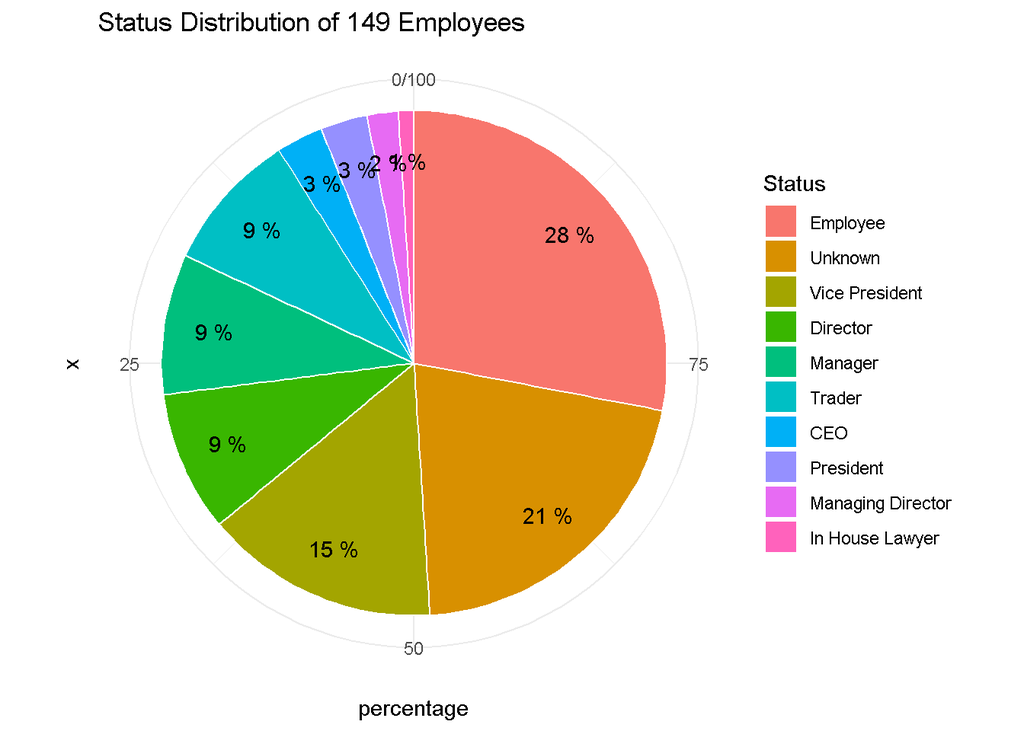

```r
#Create the table to calculate the percentage of each status
status_percentage = emails %>%
  distinct(employee_id, .keep_all = TRUE) %>%
  group_by(status) %>%
  summarise(count = n()) %>%
  mutate(percentage = round(count / sum(count) * 100)) %>%
  arrange(desc(percentage))

# Create the pie chart of status

#This library will help to sort the portion
library("forcats")
#We sort the "status" by the value of "percentage"
Status = fct_infreq(status_percentage$status,w= status_percentage$percentage)

ggplot(status_percentage, aes(x="", y=percentage, fill= Status))+
  geom_bar(width = 1, stat = "identity", color = "white")+
  coord_polar("y", start=0, direction = -1)+
  theme_minimal()+
  ggtitle("Status Distribution of 149 Employees") +
  geom_text(aes(x=1.3, label=paste(percentage,"%")),position = position_stack(vjust=0.5))
```

Through the chart, we can see that nearly 30% of the employees hold the position of Employee, making up the largest portion. At the same time, about 1/5 of the employees have an “Unknown” status, indicating that there may be a lot of information that has been deleted or hide to cover up. High-level management positions such as Vice President, Director, and Manager also account for a significant proportion.

### 4.2. Most popular messages

Now we will see some messages which appear the most in the database:

```r
most_popular_message_id = activities %>%
  group_by(mes_id) %>%
  summarize(count = n()) %>%
  arrange(desc(count)) %>%
  slice_head(n=10)

most_popular_message =  left_join(most_popular_message_id, activities, by = "mes_id") %>%
  select(mes_id, count, subject) %>%
  distinct(mes_id, .keep_all = TRUE) %>%
  arrange(desc(count))

most_popular_message_plot = ggplot(most_popular_message, aes(x = reorder(interaction(mes_id, subject),count) , y = count)) +
  geom_bar(stat = "identity", fill = "#87CEEB") +
  labs(title = "Top 10 popular messages",
       x = "Messageid - Name of the message",
       y = "Number of message") +
  coord_flip() +
  geom_text(aes(label = count), vjust = 0)+
  theme(axis.text.x = element_text(angle = 90, vjust = 0.5, hjust = 1))
```

Since the data wasn’t clear when displayed, I took a screenshot of the chart in full window mode:

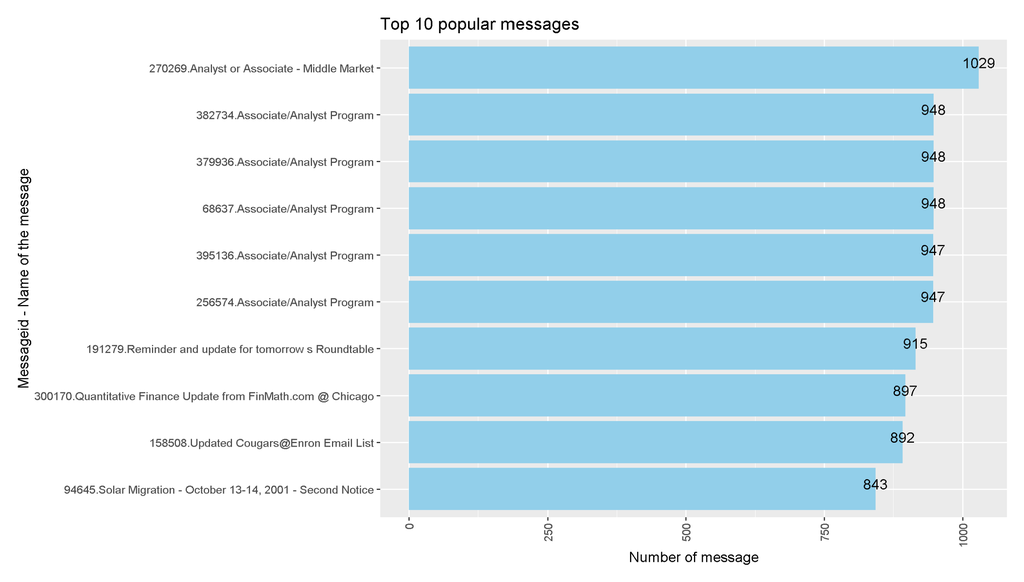

### 4.3. Most popular subjects

We do some analysis about most popular subjects and see if there is any difference with most popular messages :

```r
most_popular_subject = activities %>%
  filter(subject_content != "") %>%
  group_by(subject_content) %>%
  summarize(count = n()) %>%
  arrange(desc(count)) %>%
  slice_head(n=15)


most_popular_subject_plot = ggplot(most_popular_subject, aes(x = reorder(subject_content,count) , y = count)) +
  geom_bar(stat = "identity", fill = "#87CEEB") +
  labs(title = "Most popular subject",
       x = "Subject",
       y = "Number of message") +
  coord_flip() +
  geom_text(aes(label = count), vjust = 0)+
  theme(axis.text.x = element_text(angle = 90, vjust = 0.5, hjust = 1))
```

Since the data wasn’t clear when displayed, I took a screenshot of the chart in full window mode:

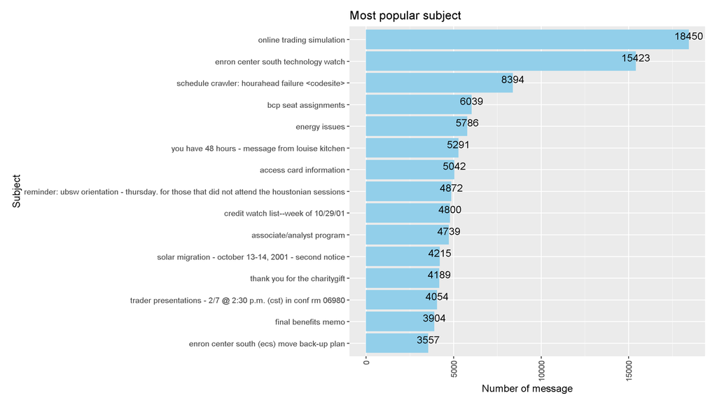

From the chart of most popular subjects, we can see that it generally has a higher volume compared to the chart of most popular messages. This is normal because one subject can be repeated many times. Each time it is sent, responded to, or forwarded, it will be recorded with a new message ID.

Another point to see is some subjects possibly related to Enron Online (EOL), an energy trading platform created by them (for example “online trading simulation”), a significant part of the company’s operations and played a role in the scandal. According to the [Applied Corporate Governance page](https://www.applied-corporate-governance.com/wp-content/uploads/2018/04/Enron-Case-Study.pdf), “…its hidden cost was the great increase in capital requirement of the trading business. This became a dramatic problem later. Meanwhile, it gave Enron the opportunity to manipulate the market.”.

## 5. Data analysis

### 5.1 The most active Enron employees in the email database

We will identify the most active employees in the company using two approaches: by the number of emails sent and by the number of employees with the highest frequency of sending messages:

- Vision 1: Most active senders

```r
most_send_emails = activities %>%
  group_by(email_sender) %>%
  summarise(count =n()) %>%
  arrange(desc(count)) %>%
  slice_head(n = 10)

#Create the histogram
most_send_emails_plot =
ggplot(most_send_emails, aes(x = reorder(email_sender, count), y = count)) +
  geom_bar(stat = "identity", fill = "#87CEEB") +
  labs(title = "Top 10 email senders",
       x = "Sender",
       y = "Number of email") +
  coord_flip() +
  geom_text(aes(label = count), hjust = 0) +
  theme(axis.text.x = element_text(angle = 90, vjust = 0.5, hjust = 1))
```

Since the data wasn’t clear when displayed, I took a screenshot of the chart in full window mode:

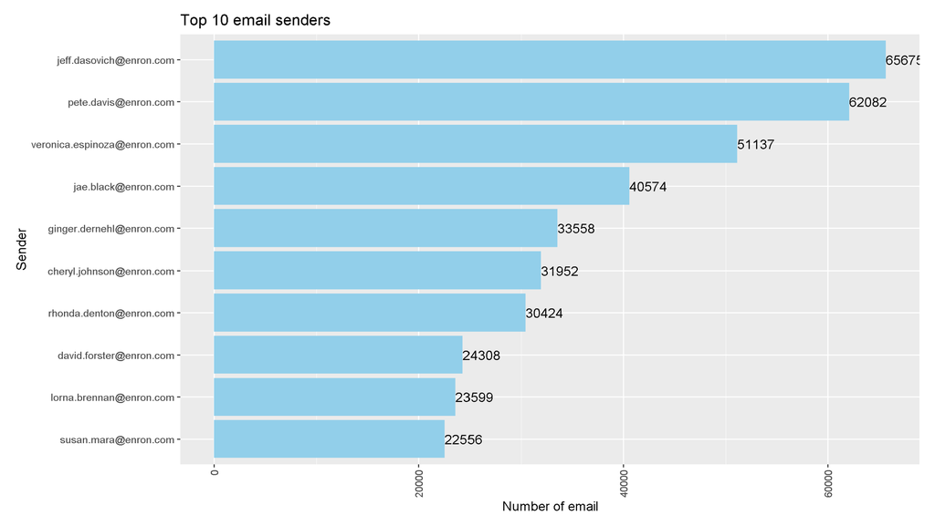

- Vision 2: Most active Enron’s employees

```r
most_send_employee = activities %>%
  left_join(emails,by = c("email_sender" = "email_id"))%>%
  mutate(full_name = paste(firstName,lastName)) %>%
  group_by(full_name) %>%
  summarise(count =n()) %>%
  arrange(desc(count)) %>%
  slice_head(n=15)

most_send_employee_plot = ggplot(most_send_employee, aes(x = reorder(full_name, count), y = count)) +
  geom_bar(stat = "identity", fill = "darkblue") +
  labs(title = "Most active Enron's employees",
       x = "Name of employee",
       y = "Number of email sent") +
  coord_flip() +
  geom_text(aes(label = count), hjust = 0) +
  theme(axis.text.x = element_text(angle = 90, vjust = 0.5, hjust = 1))
```

Since the data wasn’t clear when displayed, I took a screenshot of the chart in full window mode:

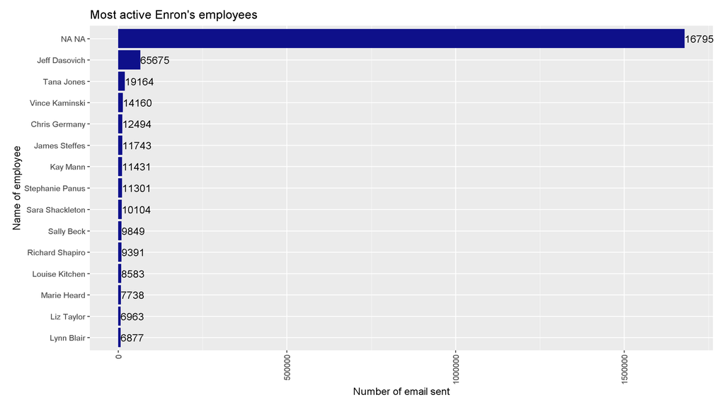

In these 2 charts, Jeff Dasovich is the most active employee who sent the most emails, with a total of 65675 emails.

### 5.2 Analysis of the role of the different users

We will examine whether there is any difference between the number of emails sent and received across different statuses:

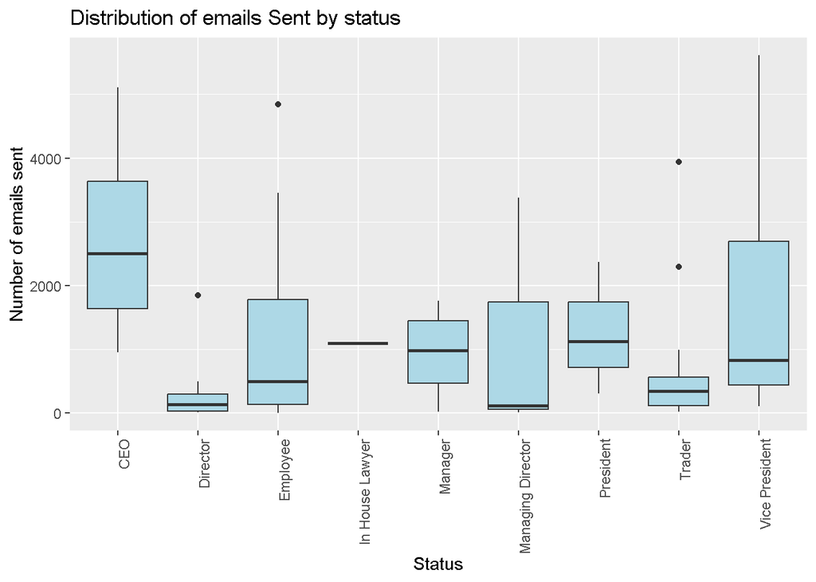

```r
#Calculate sent emails per status
sent_emails = activities %>%
  group_by(email_sender) %>%
  summarise(sent_count = n()) %>%
  left_join(emails, by = c("email_sender" = "email_id")) %>%

  #After the joining process, there are cases that the status has the NA value because some emails don't exist in the "emails" table, so we have to switch those NA values to "Unknown", and since it creates the noise, so we will drop this value
  replace_na(list(status = "Unknown")) %>%
  filter(status != "Unknown") %>%

  #There are a lot of extreme value (noise) so we decided to select the number of sent email which is less than 6000 so see easily the chart
  filter(sent_count <= 6000)

#Calculate received emails per status
received_emails = activities %>%
  group_by(email_recipient) %>%
  summarise(received_count = n()) %>%
  left_join(emails, by = c("email_recipient" = "email_id")) %>%
  replace_na(list(status = "Unknown")) %>%
  filter(status != "Unknown") %>%

  #There are also a lot of extreme value so the number of sent email which is less than 8000 is selected to see easily the chart
  filter(received_count <= 8000)

#Create box plot for sent emails
sent_plot = ggplot(sent_emails, aes(x = status, y = sent_count)) +
  geom_boxplot(fill = "lightblue") +
  theme(axis.text.x = element_text(angle = 90, hjust = 1)) +
  labs(title = "Distribution of emails Sent by status", x = "Status", y = "Number of emails sent")

#Create box plot for received emails
received_plot = ggplot(received_emails, aes(x = status, y = received_count)) +
  geom_boxplot(fill = "lightgreen") +
  theme(axis.text.x = element_text(angle = 90, hjust = 1)) +
  labs(title = "Distribution of emails received by status", x = "Status", y = "Number of emails received")

sent_plot
```

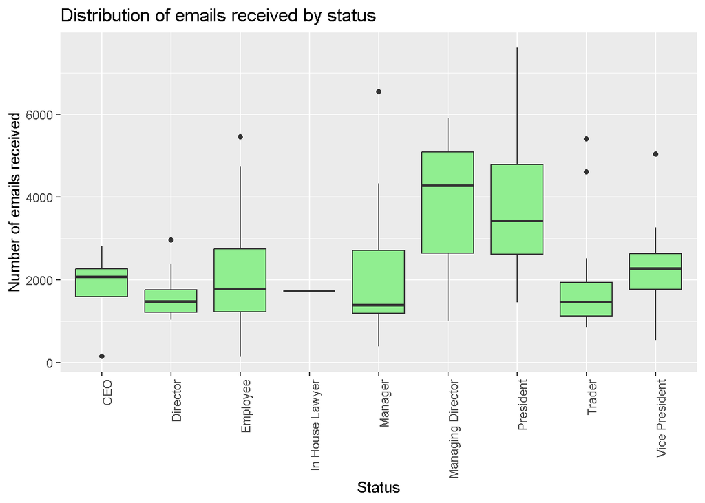

```r
received_plot
```

### 5.3. Temporal dynamic of the messages

Here is the chart of the number of message over time:

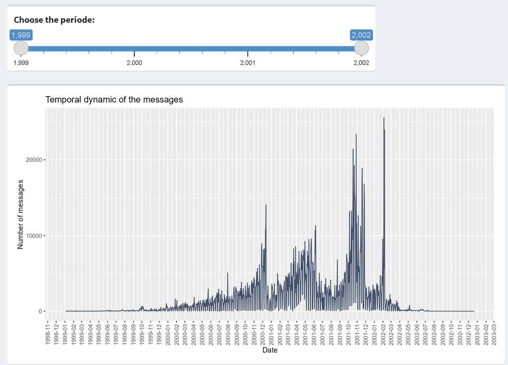

### 5.4. Temporal dynamic of the sent emails by status

When using the chart of sent emails categorized by status, combined with the chart of most discussed subjects over time, we can trace and explain some behaviors of the statuses.

For instance, when filtering for the year 2001 and the status of CEO, we can see an unusual increase in the number of emails sent in August 2001, this could be explain due to the Skilling’s resignation announcement, and Lay is named CEO:

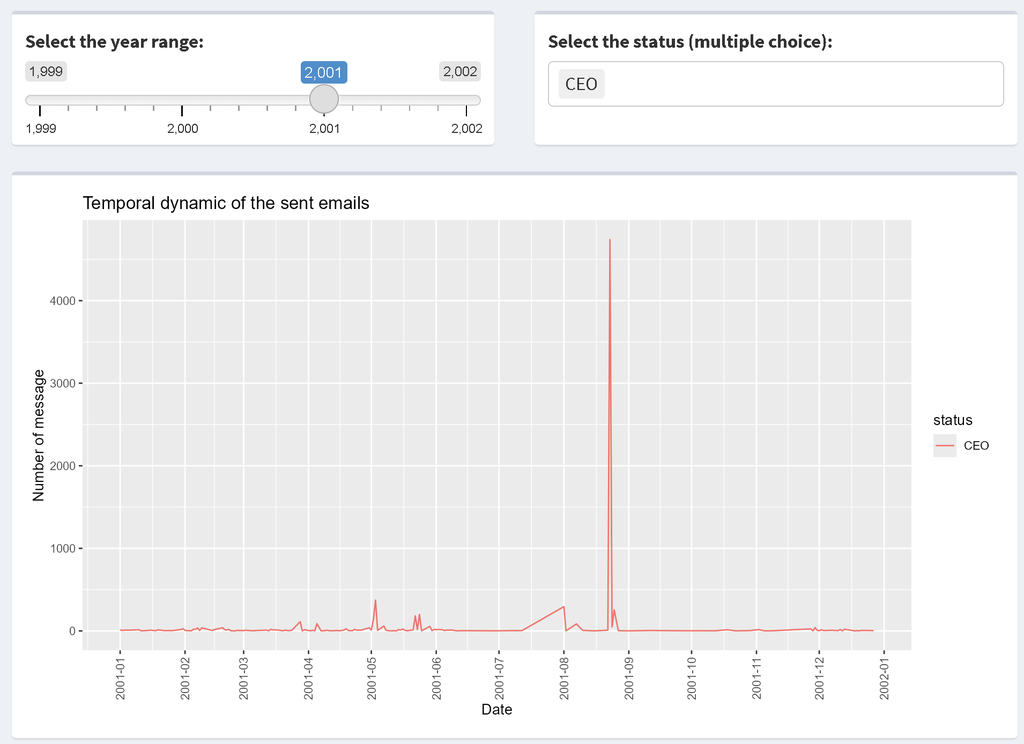

When combining the analysis with the chart of most discussed subjects over time, we can easily see that there are also about 4,700 emails with the subject “associate/analyst program”. It is very likely that the CEOs sent emails on this topic:

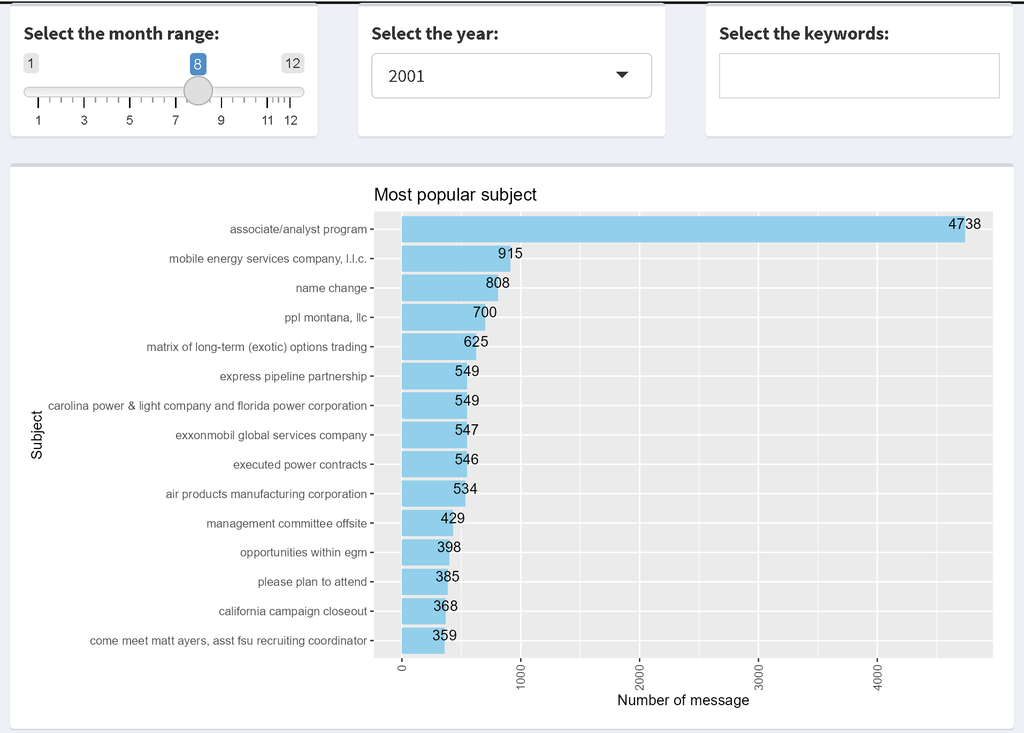

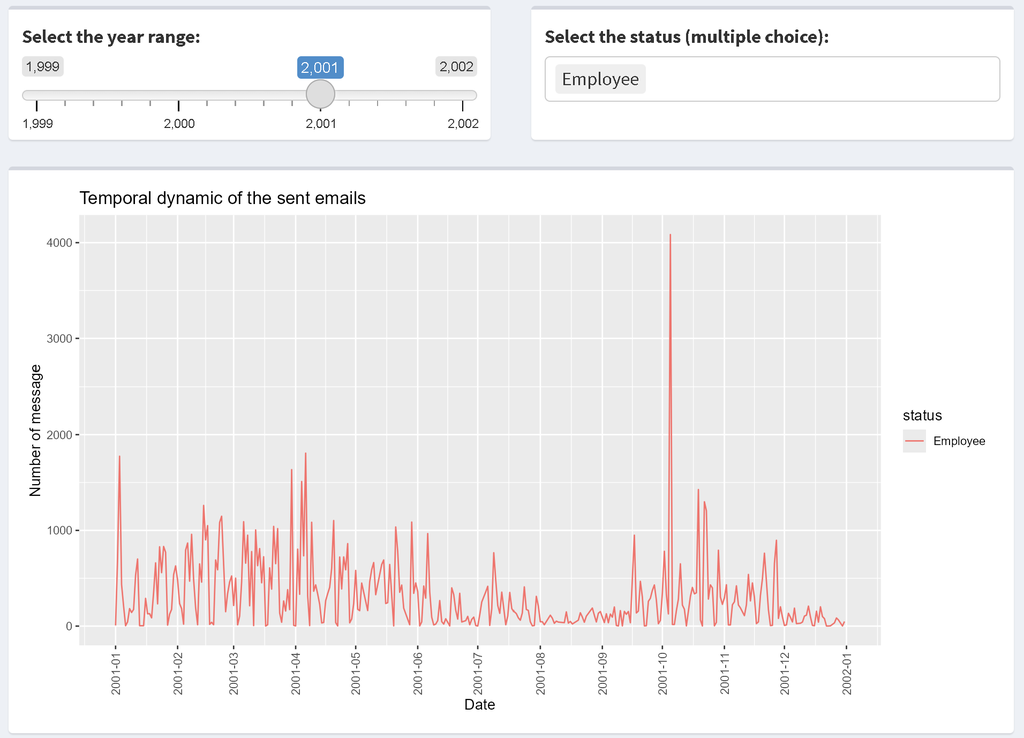

### 5.5. Content analysis

We will see most discussed subjects over time, this is a upgrade version of the old most popular subject chart.

When using filters for time and subject, we can recognize many topics related to the Enron scandal that appear. Although a lot of emails may have been destroyed by the auditing firm Arthur Andersen, there are still many topics showing Enron’s activities during the period when the company was about to go bankrupt (topics related to FERC, the California electricity crisis…):

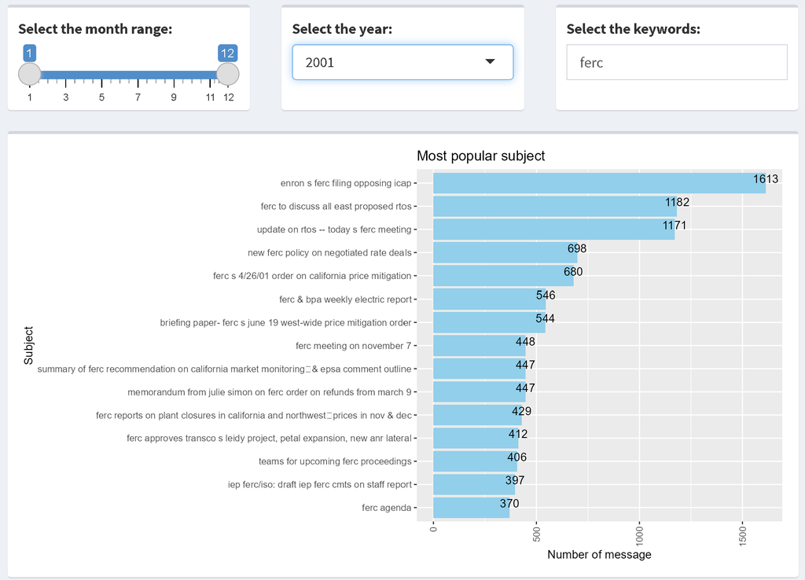

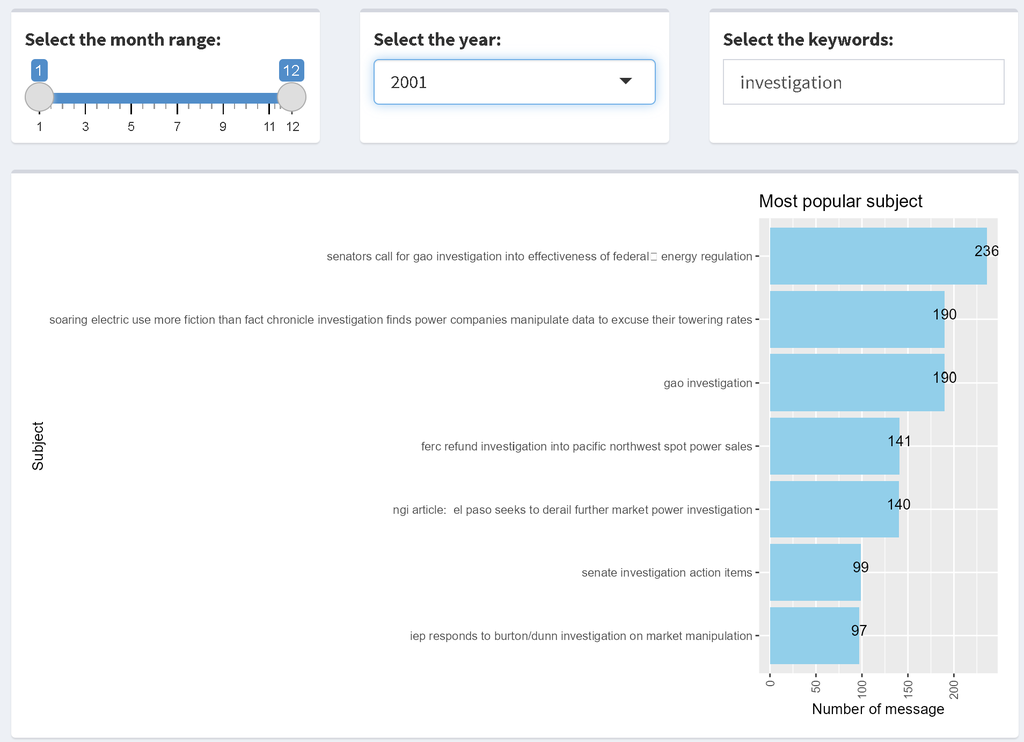

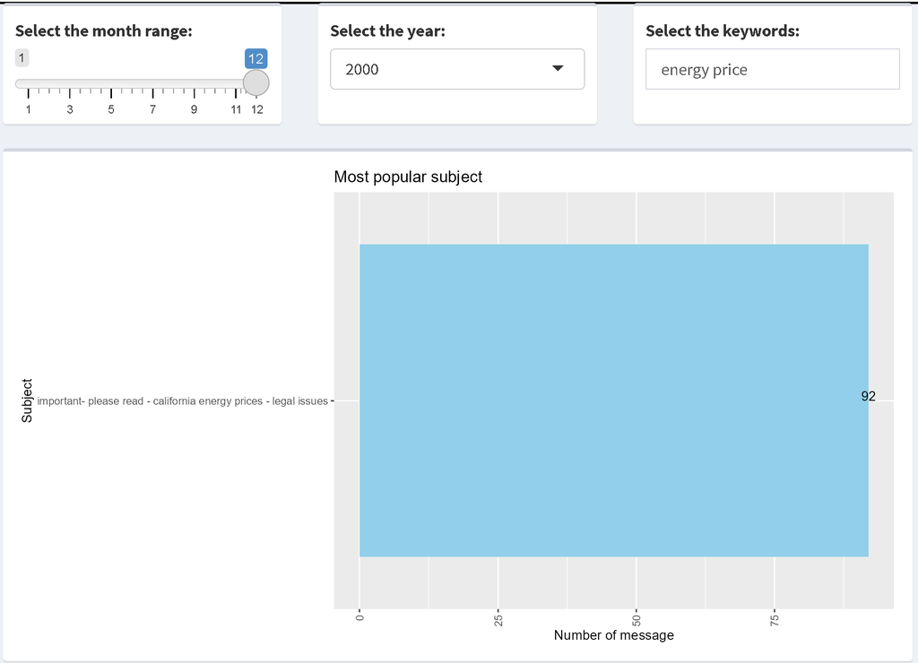

In the section 5.3, we know that the number of messages increased anomalously in February 2002. When using this chart above to analyze the content more deeply, we found that a large number of these messages were related to “online trading simulation.” This could be linked to Enron’s energy trading platform, Enron Online (EOL), which was also a factor in the scandal as Enron used it to manipulate electricity market prices:

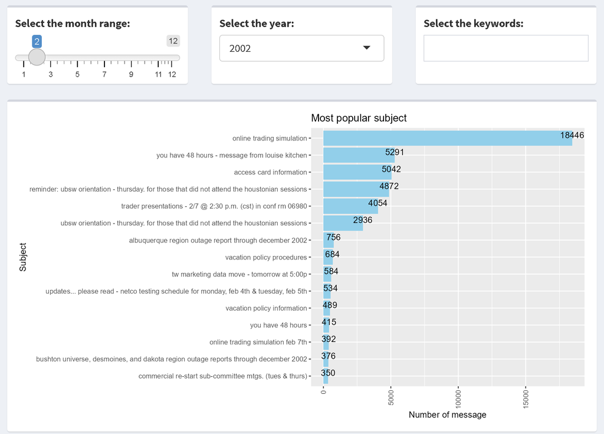

## 6. Create the Shiny application

```r
library(shiny)
library(shinyWidgets)
library(shinydashboard)
library(dslabs)
library(tidyverse)
```

```r
library(plotly)
```

### 6.1. Create the UI

In this part, we will create the UI for the Shiny application. We will create a dashboard page with a sidebar menu that shows a list of charts. Each time we click on a bar, it will display the corresponding chart.

```r
ui = dashboardPage(
  dashboardHeader(title = "Enron emails"),
  dashboardSidebar(

    #We create the side bar Menu, the tab Name will help to connect with the tab Item, which helps to access to the right chart each time we click on a menu item
    sidebarMenu(
      menuItem("Most active emails", tabName = "most_send"),
      menuItem("Most active employees", tabName = "most_active"),
      menuItem("Most active emails by status", tabName = "emails_status"),
      menuItem("Frequency of messages overtime", tabName = "frequency"),
      menuItem("Number of emails sent by status", tabName = "sent_status_overtime"),
      menuItem("Most discussed subjects", tabName = "subject_overtime"))),
  dashboardBody(
     tabItems(

      #We create the UI for the question of most active mails
      tabItem(tabName = "most_send", fluidRow(
        box(plotOutput("most_send"), width = 12))),

      #Then, we will create the UI for the question of most active mails by status and add 2 action buttons
      tabItem(tabName = "emails_status", fluidRow(
        actionButton("status_sent", "Show sent emails plot"),
        actionButton("status_received", "Show received emails plot"),
        box(plotOutput("emails_status"), width = 12))),

      #We create the UI for the question of most active employees
      tabItem(tabName = "most_active", fluidRow(
        box(plotOutput("most_active_employees"), width = 12))),

      #Here is the UI for the question of temporal dynamic of the messages
      tabItem(tabName = "frequency",fluidRow(
        box(sliderInput("year_range", "Choose the periode:", min = 1999, max = 2002, value = c(2000, 2001)), width = 9, height = "100px"),
        box(plotOutput("messages_overtime"), width = 12))),

      #Create the UI for the sent emails by status overtime
      tabItem(tabName="sent_status_overtime",fluidRow(
        box(sliderInput("year_range_1", "Select the year range:", min = 1999, max = 2002, value = c(2000,2001)), height = "100px"),
        box(selectInput("status_choice","Select the status (multiple choice):", choices = unique(emails %>% distinct(status) %>% filter(status != "Unknown")), multiple = TRUE, selected = "CEO"), height = "100px"),
        box(plotOutput("sent_status_overtime"), width = 12))),

      #Create the UI for the most popular subject over time
      tabItem(tabName = "subject_overtime",fluidRow(

        #We add a slicer to choose the month range
        box(sliderInput("month_range", "Select the month range:", min = 1, max = 12, value = c(9,10)), height = "100px", width = 4),
        #Add a choice box to choose the year
        box(selectInput("year_choice","Select the year:", choices = c(1999,2000,2001,2002), multiple = FALSE, selected = 2001), height = "100px", width = 4),
        #Add a text input to filter the subject containing the words that we input
        box(textInput("keyword", "Select the keywords:","online"), height = "100px", width = 4),
        box(plotOutput("subject_overtime"), width = 12)
      )

  ))))
```

### 6.2. Create the server

In the server, we put and integrate the calculation part and the plot part because there are some charts that need the widgets to filter and connect with the UI, creating interactive chart.

```r
server = function(input, output) {

  output$most_send = renderPlot({
    most_send_emails_plot
  })

  output$emails_status = renderPlot({
    sent_plot
  })

  observeEvent(input$status_sent, {
    output$emails_status = renderPlot({ sent_plot })
  })

  observeEvent(input$status_received, {
    output$emails_status = renderPlot({ received_plot })
  })

  output$most_active_employees = renderPlot({
    most_send_employee_plot
  })

  output$messages_overtime = renderPlot({

    #We create the calculation and the plot for the question of temporal dynamic of the messages
    messages_overtime_count = activities %>%
      filter(year >= input$year_range[1] & year <= input$year_range[2]) %>%
      group_by(date) %>%
      summarise(count = n()) %>%
      mutate(year = year(date))

    #Make the plot for the calculation above
    messages_overtime_plot = ggplot(data = messages_overtime_count, aes(x = date, y = count)) +
      geom_line(color = "#3E4E68") +
      labs(title = "Temporal dynamic of the messages",
           y = "Number of messages",
           x = "Date") +
      scale_x_date(date_labels = "%Y-%m", date_breaks = "1 month") +
      theme(axis.text.x = element_text(angle = 90, vjust = 0.5, hjust = 1))

    messages_overtime_plot})

  #We create the calculation and plot for the sent mails by status overtime
  output$sent_status_overtime =renderPlot({

    #Create the calculation of sent emails over time
    sent_overtime = activities %>%
      filter(year >= 1999 & year <= 2002) %>%
      left_join(emails, by = c("email_sender" = "email_id")) %>%
      filter(status != "Unknown") %>%
      group_by(date,status) %>%
      summarise(count = n()) %>%
      ungroup()

    #We have to integrate the year range in the calculation
    filtered_sent_status = sent_overtime %>%
      filter(year(date) >= input$year_range_1[1] & year(date) <= input$year_range_1[2]) %>%
      filter(status %in% input$status_choice)

    #Make the plot of sent emails over time
    sent_overtime_plot = ggplot(data = filtered_sent_status, aes(x=date, y=count, color = status)) +
  geom_line() +
  labs(title = "Temporal dynamic of the sent emails",
       y = "Number of message",
       x = "Date") +
    scale_x_date(date_labels = "%Y-%m", date_breaks = "1 month") +
    theme(axis.text.x = element_text(angle = 90, vjust = 0.5, hjust = 1))
    sent_overtime_plot
  })

  #Create the calculation and plot for most popular subjects overtime
  output$subject_overtime = renderPlot({

    most_popular_subject = activities %>%
    filter(year %in% input$year_choice) %>%
    filter(subject_content != "") %>%
    group_by(date,subject_content) %>%
    summarize(count = n()) %>%
    arrange(desc(count)) %>%
    slice_head(n=15)

    most_popular_subject_1 = most_popular_subject %>%
    filter(month(date) >= input$month_range[1] & month(date) <= input$month_range[2])

    #We will make a condition, if the keyword is empty, we won't filter data, if we input some words in the box, it will match and filter the subject containing those words
    if (input$keyword != "")
      {most_popular_subject_1 = most_popular_subject_1 %>%
            filter(grepl(input$keyword,subject_content))}

    most_popular_subject_2 = most_popular_subject_1 %>%
    group_by(subject_content) %>%
    summarise(count = sum(count)) %>%
    arrange(desc(count)) %>%
    slice_head(n = 15)

    #Create the plot of most popular subjects
    most_popular_subject_plot = ggplot(most_popular_subject_2, aes(x = reorder(subject_content,count) , y = count)) +
  geom_bar(stat = "identity", fill = "#87CEEB") +
  labs(title = "Most popular subject",
       x = "Subject",
       y = "Number of message") +
  coord_flip() +
  geom_text(aes(label = count), vjust = 0)+
  theme(axis.text.x = element_text(angle = 90, vjust = 0.5, hjust = 1))

    most_popular_subject_plot})

}
```

### 6.3. Run the Shiny application

```r
shinyApp(ui, server)
```

Shiny applications not supported in static R Markdown documents

## 7. Conclusion

The Enron email dataset provides critical insights into the events leading to one of the most infamous corporate scandals in history. Spikes in activity can be linked to significant occurrences like the California energy crisis, the SEC inquiry, and the final bankruptcy filing by analyzing email communication patterns. Increased internal activity, probably related to damage management, fraud concealment, and litigation strategy, is reflected in the spike in email traffic during critical months. This investigation demonstrates how organizational behavior during crises can be uncovered using communication data.

Analysis is limited by the large number of emails in the Enron email dataset that have unidentifiable employees or missing subjects. Network analysis can be used in future research to find hidden patterns. We can gain a deeper insight of organizational dynamics and information flow by examining CC, BCC, reply chains, and forwarded emails to uncover direct communication and covert interactions.